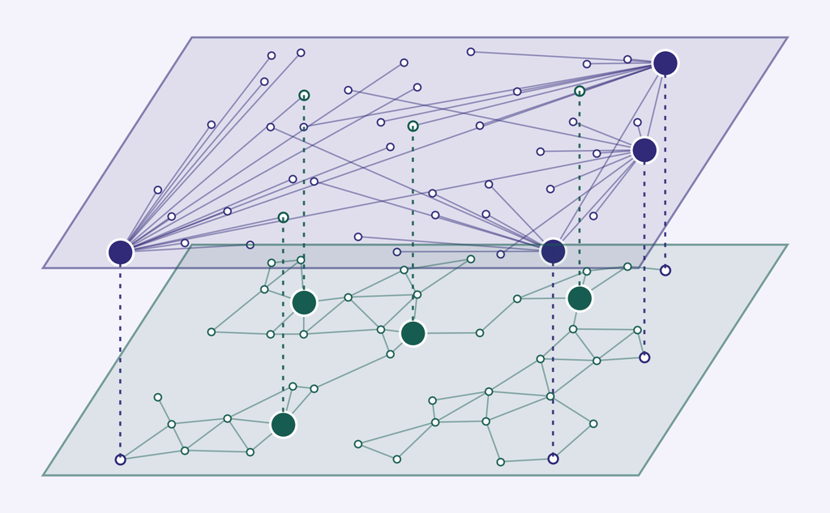

# The Ties That Open a Community Are Not the Ties That Move It

Task-Specific Relational Advantage in Diffusion

Roberto Cantillan & Mauricio Bucca

Department of Sociology | Pontificia Universidad Católica de Chile

# I. The Problem and the Argument

## Two Questions About Diffusion

QUESTION 1

#### Who carries an innovation *into* a community?

Entry points, seeds, opinion leaders: the actors an organization or a campaign approaches first.

QUESTION 2

#### Who carries the community *into* the innovation?

The households that decide, one by one, whether to take it up.

Targeting strategies answer the first question. They usually leave open whether **the same relational position** also answers the second.

Valente & Davis 1999; Banerjee et al. 2013, 2019; Beaman et al. 2021

## Two Literatures, One Missing Question

STRUCTURAL WORK

#### The returns to targeting depend on how ties are organized

Complex contagion, network paradoxes, multiplex seeding.

Centola & Macy 2007; Hsiao & Christakis 2026; Chandrasekhar et al. 2026

MULTIPLEX WORK

#### Relations are not interchangeable channels

Pooling them can hide the one that matters for an outcome.

Omodei & Arenas 2016; Becker et al. 2020; Larson & Rodríguez 2023

Both show that **different relations matter**. Neither asks whether an advantage established for one task **survives a change of task**.

## A Diffusion Process Is a Sequence of Tasks

A **task** is a stage of the process, defined by what must happen for it to advance and by the criterion that **orders actors’ advantage** for it.

Each task orders the same population. The theory asks whether those **orderings agree**.

Cf. Rule, Sabetta & Bearman 2026: events matter when they are tied into subsequent streams of action.

## Two Households in a Village

HOUSEHOLD A

#### The schoolteacher

Neighbors consult the household for **information** and for help with **important decisions**.

What an organization sees Prominence is visible and advice is sought: a natural **entry point**.

HOUSEHOLD B

#### The family whose home is visited daily

Its members visit others in turn: routine **co-presence** with neighbors.

What adoption may require Seeing how others like oneself manage repayments, coordinating with them, relying on them when things go wrong.

The advantage that made A a good point of entry **need not carry into adoption**.

## Nonportability Needs Three Conditions Together

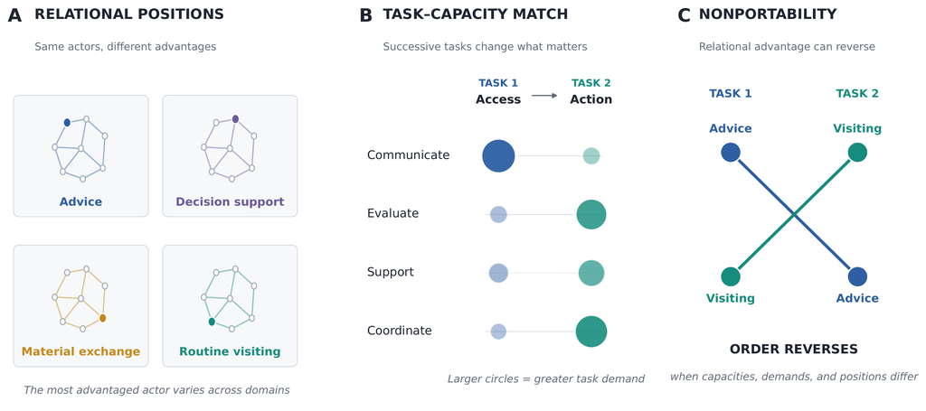

**(1)** Relations supply different capacities. **(2)** Tasks demand them in different proportions. **(3)** Actors stand differently across relations.

## Advantage Is a Match Between a Position and a Task

$$\color{#4f46a5}{R_{ir}}\;=\;\color{#a8433b}{\sum_{l}}\;\color{#b07d1e}{\omega_{lr}}\;\color{#175c50}{x_{il}}$$

$R_{ir}$

Relevant position

How well placed household $i$ is **for task $r$**

$\sum_l$

A weighted blend

Add up the domains $l$, each counted by how much it matters

$\omega_{lr}$

Fit

How much task $r$ draws on what domain $l$ makes possible

$x_{il}$

Standing

Where $i$ sits in domain $l$: central, or at the edge

One household can be central in one domain and peripheral in another. **Which standing counts depends on the task.**

## When Does Advantage Change? An Exact Identity

$$\color{#4f46a5}{R_{i2}-R_{i1}}\;=\;\color{#175c50}{\frac{s}{2}}\;\color{#b07d1e}{(\tau_2-\tau_1)}\;\color{#a8433b}{(x_{i1}-x_{i2})}$$

$R_{i2}-R_{i1}$

Change in advantage

How much household $i$’s relevant position moves from task 1 to task 2

$s$

Differentiation

How different the two domains are ($\tfrac12$ simply averages them)

$s=0$: domains interchangeable

$\tau_2-\tau_1$

Task shift

How far the demands move from one task to the other

$\tau_1=\tau_2$: identical demands

$x_{i1}-x_{i2}$

Household profile

How much more central $i$ is in domain 1 than in domain 2

$x_{i1}=x_{i2}$ for all: same standing

It is a **product**: if any one factor is zero, advantage does not change. This separates the argument from the weaker claim that “different networks matter.”

## Three Testable Implications

H1 · POSITIONAL DIFFERENTIATION

Relational domains **rank the same actors differently**.

Condition Observable without any outcome.

H2 · REVERSAL

The domain that orders actors for **program entry** differs from the domain that orders them for **adoption**.

Core test Same households, two tasks.

H3 · CONCEALMENT

**Aggregate** centrality predicts adoption worse than centrality in the domain H2 identifies.

Why A union network gives weight to irrelevant domains.

A fourth, **pre-specified secondary test**: the entry pool’s advantage should weaken where domains correspond less. It relies on variation *between* villages, so we treat it as moderation, not as a pillar.

# II. Design: Three Kinds of Evidence

## Setting: Microcredit Entering 75 Karnataka Villages

10,618

households with network and adoption data

49

villages (structural comparisons use all 75)

2006

networks measured about six months before the lender entered

17.3%

of households adopted a BSS loan

- BSS entered by inviting households with **locally influential roles** (teachers, self-help group leaders, shopkeepers): 12% of households.
- BSS **did not observe the networks**: the rule is a role-based entry strategy of the kind organizations commonly use.
- Because networks **precede** entry, adoption cannot have produced the measured positions.

Banerjee, Chandrasekhar, Duflo & Jackson 2013

## Same Households, Three Relational Layers

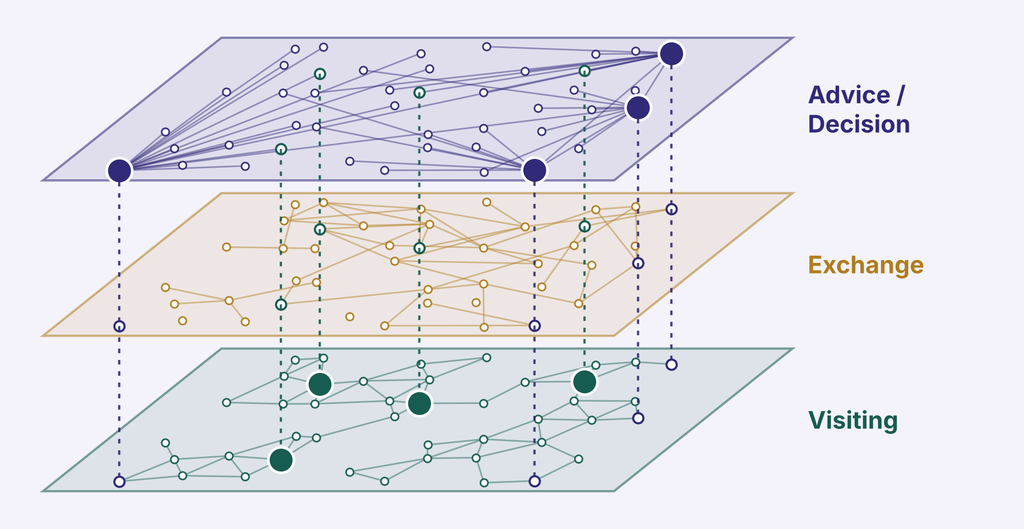

The households are the same in every layer. **Who is central changes with the relation.** Schematic illustration, not data.

## Three Relational Domains, One Position Measure

| Domain | Name generators | Capacities made plausible | Mean degree |
| --- | --- | --- | --- |
| **Advice/Decision** | Seeks advice from; turns to for help with an important decision | Communicative and deliberative access; judgment | 3.2 |
| **Exchange** | Borrows money from; lends money to | Material support; risk buffering | 4.2 |
| **Visiting** | Visits the other’s home; is visited | Observation of ordinary conduct; coordination; co-presence | 5.3 |

Labels identify **relational infrastructures**, not the content that passed through a tie in a particular decision.

## How Position Is Measured

**Position** = a household’s *diffusion centrality* in each domain, normalized to $[0,1]$ **within each village**.

$$\mathrm{DC}(i)=\color{#175c50}{\Big[}\;\color{#a8433b}{\sum_{t=0}^{T}}\;\color{#4f46a5}{(qA)^{t}}\;\color{#b07d1e}{\mathbf 1}\;\color{#175c50}{\Big]_i}$$

$A$, $q$

Who is tied to whom in the domain; $q$ damps each further step

$\sum_{t=0}^{T}$

Count walks of every length from 0 up to the layer’s diameter

$\mathbf 1$

Everyone starts equal: one unit of information per household

$[\cdot]_i$

Read off household $i$: the expected reach of information that starts there

A household is central when information that starts there **travels far** through the domain’s ties, and the score is compared **within its own village**.

## Same Households, Two Tasks

$$\color{#4f46a5}{Y^{k}_{iv}}=\color{#175c50}{\alpha^{k}_v}+\color{#b07d1e}{\sum_{l\in\{AD,E,V\}}\beta^{k}_l\,\mathrm{DC}_{liv}}+\color{#a8433b}{\mathbf{X}'_{iv}\gamma^{k}}+\color{#5b6b7a}{\varepsilon^{k}_{iv}}$$

$Y^{k}_{iv}$

Outcome

Did household $i$ in village $v$ become an entry point ($G$) or adopt ($U$)?

$\alpha^{k}_v$

Village baseline

Compare households only **within** their own village

$\beta^{k}_l\,\mathrm{DC}_{liv}$

Position pays

How much more likely the outcome is for a household that is more central in domain $l$

$\mathbf{X}'\gamma$

Controls

Union degree, wealth, survey participation; the same in both models

$\varepsilon$

Everything else

What the model does not explain

Two outcomes, one model each: **entry designation** (a leader household chosen by the lender as an entry point) and **adoption** (took up a BSS loan). Both are the household’s own, so the object is **positions**, not influence.

## The Reversal Estimand

$$\color{#4f46a5}{\Theta}=\color{#175c50}{\big(\beta^{U}_{V}-\beta^{U}_{AD}\big)}-\color{#b07d1e}{\big(\beta^{G}_{V}-\beta^{G}_{AD}\big)}$$

$\beta^{U}_{V}-\beta^{U}_{AD}$

The gap at adoption

How much more **Visiting** than **Advice/Decision** centrality predicts taking up the loan

$\beta^{G}_{V}-\beta^{G}_{AD}$

The gap at entry

The same Visiting-minus-Advice gap, now for being designated an entry point

$\Theta$

A contrast of contrasts

How much the gap **flips** between entry and adoption. Zero means one ordering serves both tasks

$\Theta=0.451$, SE $0.103$

$\Theta$ is **not** the causal effect of a position. It asks only whether different domains order the same households differently for different tasks.

## Triangulation: Three Designs, Three Different Questions

PRIMARY TEST

#### Within-BSS comparison

Question Do different domains order the **same households** for entry and for adoption?

Evidence 10,618 households, 49 villages; networks measured before entry.

Cannot show Causal effects of a position; how information traveled.

INDEPENDENT BENCHMARK

#### Randomized seeding experiment

Question For the **information task**, which seed position yields more reach?

Evidence 68 villages; 3 or 5 seeds assigned at random within each village.

Cannot show Entry or adoption of the same households as BSS.

SCOPE CONDITION

#### Formal model and simulation

Question When does reordering among individuals become a **collective cost**?

Evidence Conditions derived; 100 network pairs per cell; observed-network upper bound.

Cannot show What BSS actually gained or lost.

The legs have **different units, villages and outcomes**. Each answers one question; we **never pool them** into a single estimate.

## Rival Explanations We Take Seriously

| Threat | What could produce the pattern | What we do |
| --- | --- | --- |
| **General prominence** | Visiting just marks wealthier or more active households | Control union degree and wealth; compare opposite relational profiles after balancing on prominence; drop the entry pool |
| **Composition, homophily** | Caste structures both relations and access to credit | Sub-caste fixed effects; residualize on caste, religion, housing; estimate by caste |
| **Spatial proximity** | Visiting is the most local relation; neighbors share exposure | Census enumeration order as a proxy; split Visiting ties into near and far |
| **Measurement** | Sampled respondents; composites; the pool is not the households contacted | Each constituent name generator; four scales; four sample restrictions |

A generic prominence account predicts the **same households lead in both tasks**, not that different domains order them for different tasks.

# III. Results

## H1: The Domains Rank Households Differently

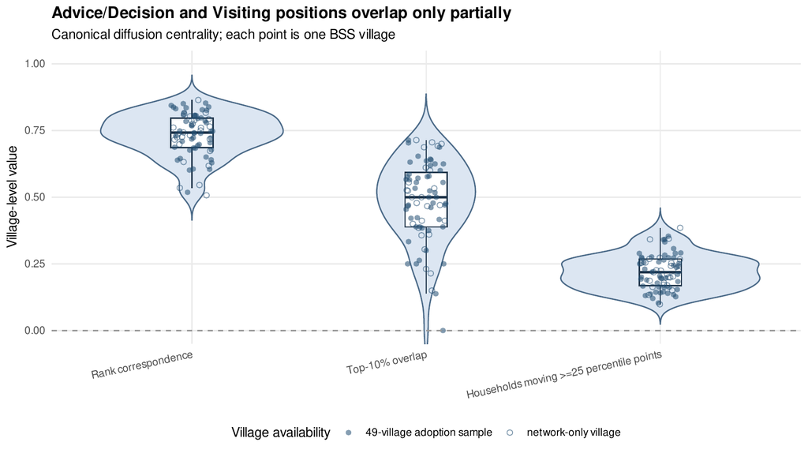

Across 75 villages, the within-village Spearman correlation between the Advice/Decision and Visiting rankings has a median of **.742** (IQR .686 to .796).

In the median village, only **half** of the top decile in one domain is in the top decile of the other.

**21.8%** of households move at least 25 percentile points between the two rankings.

Related but **far from interchangeable**: the third condition is met, though only partly.

## H2: Entry and Adoption Privilege Different Relations

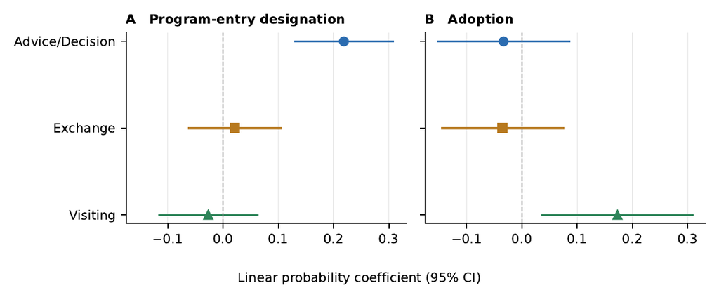

+21.9 pp

Advice/Decision → entry  
$b=0.219$, SE $0.045$, $p<.001$

+17.3 pp

Visiting → adoption  
$b=0.173$, SE $0.069$, $p=.012$

Θ = 0.451

reversal contrast  
SE $0.103$, $p<.001$

Moving from the least to the most central household in a village: the **same households** are ordered by **different relations** at the two tasks.

## The Reversal Is Not Fragile

49 / 49

leave-one-village-out estimates stay positive and significant (0.141 to 0.194)

p = .021

wild-cluster bootstrap with the null imposed

8 / 8

name-generator versions of Θ are positive (0.192 to 0.538); seven with $p<.05$

16 / 16

Visiting minus Advice/Decision contrasts positive across four scales and four samples; 15 intervals exclude zero

0.168

Visiting coefficient among households **outside** the entry pool ($p=.025$)

0.186

in the 43 original villages ($p=.011$)

Not an artifact of **construction, scaling, sample, or the entry pool itself**.

## H3: The Aggregate Network Conceals the Reversal

UNION OF ALL RELATIONS

−0.025

union centrality → adoption  
SE $0.070$, $p=.72$

VISITING ALONE

+0.156

Visiting centrality → adoption  
$p=.030$

Estimated jointly on the same households, Visiting exceeds the union coefficient by **0.181** (SE $0.058$, $p=.003$);  
in the model that includes both, by **0.438** (SE $0.184$, $p=.021$).

Collapsing the domains gives weight to relations that carry **no adoption signal** and dilutes the one that does.

Distinct from the village-level finding of Banerjee et al. 2013: ours concerns which households adopt *within* villages.

## What Qualifies the Result

SPATIAL PROXIMITY

The adoption association is carried by ties between **nearby households** ($b=0.080$, $p=.017$); other Visiting ties do not ($b=0.019$, $p=.71$).

Reading Learning from neighbors **or** neighborhood differences in exposure: the data cannot separate the two.

WHO DRIVES IT

Concentrated among **lower-caste households** (interaction $b=0.159$, $p=.008$).

Balancing on prominence Visiting-oriented households adopt 2.4 pp more, interval $[-1.2, 5.9]$: consistent with, not independent confirmation of, the main result.

SECONDARY TEST: UNINFORMATIVE

Entry-pool advantage should shrink where domains diverge. The interaction is indistinguishable from zero ($b=-0.008$, $p=.96$), and cross-village variation is narrow (SD of $1-\rho_v$ is 0.08). **Neither support nor refutation.**

## An Independent Benchmark for the Information Task

- Randomized seeding experiment in the same region: **3 or 5 seed households** per village, assigned at random.
- Other households register receipt with a **missed call**.
- **68 villages**; four harmonized domains: Advice, Decision Support, Visiting, Material Exchange.
- Random assignment **within** villages identifies how the seed set’s position affects reach, holding the network fixed.

−0.684 SD

Visiting minus Advice contrast in calls per household  
randomization $p=.030$

Original scaling: $-0.717$ (conventional $p=.09$). Unique calls: randomization $p=.072$.

Seed sets central in **Advice** generated more informational reach than seed sets central in **Visiting**. The direction is stable; its precision depends on the scaling.

Chandrasekhar, Chaudhary, Golub & Jackson 2026

## Two Tasks, Two Orderings, Not One Estimate

The two studies point **separately** to the same pattern. Neither observes the same households in two successive stages, so we do not combine them.

## When Does Reordering Matter?

Simulated networks vary how much the two layers **correspond**. At complete differentiation and a complete change in task demands, correspondence falls from .952 to −.016:

A · PAIRS THAT REVERSE Who leads in task 1 no longer leads in task 2: **9.0% → 50.5%**

B · ELIGIBLE PAIRS Same share, weighting each pair by both actors’ chance of passing task 1: **a similar pattern**

C · REUSE LOSS Share of attainable task-2 reach lost by reusing the task-1 initiators: **0.7% → 36.7%**

Modest reordering is **absorbed** by redundant paths; extensive reordering makes reuse sacrifice **more than a third** of attainable coverage.

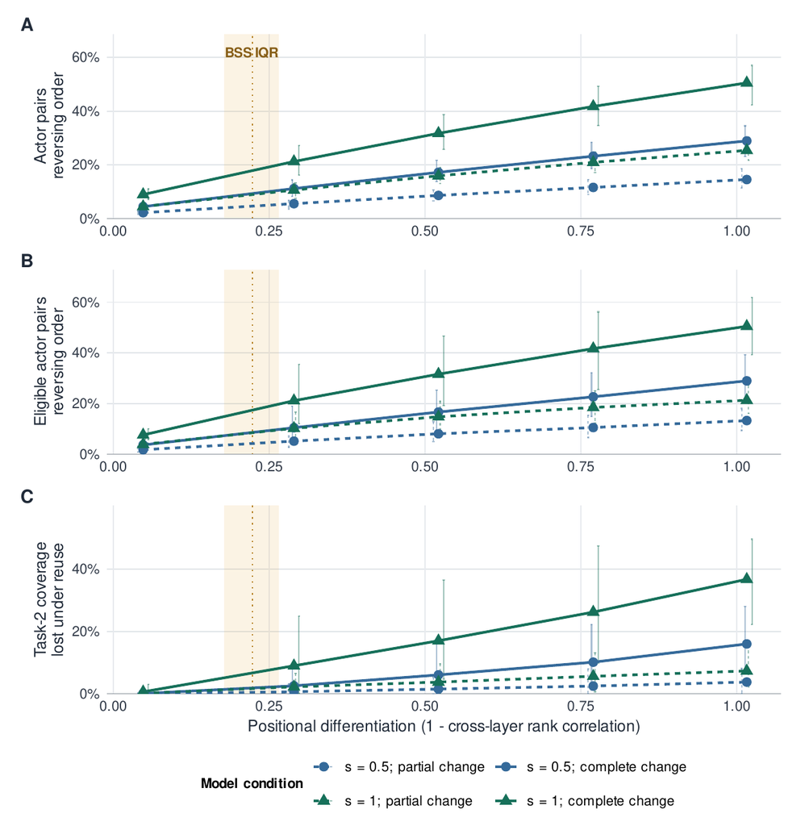

Green: complete differentiation ($s=1$); blue: intermediate ($s=.5$). Solid: complete change in task demands; dashed: partial. Shaded band: correspondence in the 75 Karnataka villages (IQR). Points: means of 100 network pairs.

## Where the Karnataka Villages Sit

.776

median cross-domain correspondence (IQR .734 to .822)

9.5% / 18.8%

pairs reversing, partial / complete shift in demands

1.6% / 6.8%

reuse loss, partial / complete shift

15.0%

upper bound on observed networks (6.6% at the lower end); 21.4% of pairs reverse

- High correspondence: reordering is real but **absorbed by redundant reach**.
- The observed-network figures treat regression coefficients as task–capacity weights: **ceilings, not estimates** of what BSS gained or lost.
- Not evidence of influence: entry-pool positions did not predict adoption within two steps of them ($b=0.002$, $p=.72$).

Low correspondence marks settings **vulnerable** to nonportability. It does not by itself predict the loss.

# IV. What It Adds

## Relational Advantage Is a Match, Not an Attribute

- Diffusion is not the spread of **one thing through one network**: it joins tasks that are sequential but **not relationally equivalent**.
- Advantage is neither a property of an actor nor a permanent property of a layer. It is a **match between a position and a task**.
- The entry rule found the households others consult. That secures an organization’s standing, but it does not locate the relations through which a community **decides whether to act**.

Before asking whether central actors matter for diffusion, ask **central in which relation, and for which task**.

Matters most where adoption is consequential: joint liability, public exposure, financial risk.

## Four Limits

1 · CONTENT Name generators identify **domains**, not what passed through a tie. The data do not identify the capacities.

2 · OBSERVATIONAL Adoption is a household’s own take-up, not influence. The Visiting association is carried by **nearby** ties; latent homophily remains possible.

3 · SECONDARY TEST Between-village variation in correspondence was **uninformative**: we cannot show that the reversal scales with differentiation.

4 · NO SHARED HOUSEHOLDS Entry versus adoption comes from BSS; information comes from another study. The two tasks are **never observed for the same households**.

These limits narrow the claim but leave the **central empirical contrast** intact.

## Thank You

In the villages we studied, the answer changed between the moment an opportunity **arrived** and the moment people **decided to take it**.

Roberto Cantillan · Mauricio Bucca  
Department of Sociology, Pontificia Universidad Católica de Chile

# Appendix

## A1. An Exploratory Contrast: Decision Support versus Advice

- Separating the generators behind Advice/Decision: **Decision Support** centrality is negatively associated with adoption (standardized $b=-0.059$, $p=.003$).
- The *relative* profile matters: Decision Support minus Advice predicts lower adoption ($b=-0.099$, $p=.005$); their sum does not ($b=-0.020$, $p=.48$).
- Sharpest among entry-pool households (interaction $b=-0.074$, $p<.001$).
- The reversal is larger when Advice/Decision is represented by the decision generator (0.495 to 0.538) than by the advice generator (0.192 to 0.287).

Deliberative prominence as such does not predict lower adoption; ranking higher as a source of decision support than of advice does. **Outside H1–H3 and exploratory.**

## A2. When Do Two Actors Exchange Places?

$$\color{#4f46a5}{\left(\Delta m_{ij}+s\tau_1\Delta d_{ij}\right)}\color{#175c50}{\left(\Delta m_{ij}+s\tau_2\Delta d_{ij}\right)}<0$$

$m_i,\;\Delta m_{ij}$

Overall level

Mean position $(x_{i1}+x_{i2})/2$; the gap between $i$ and $j$

$d_i,\;\Delta d_{ij}$

Profile

Relative position $(x_{i1}-x_{i2})/2$; the gap between $i$ and $j$

$\Delta m+s\tau_1\Delta d$

Who leads in task 1

Positive if $i$ ranks above $j$ in task 1

$\Delta m+s\tau_2\Delta d$

Who leads in task 2

Positive if $i$ ranks above $j$ in task 2

A **negative product** means one leads in task 1 and the other in task 2: they exchange places. A shift common to all actors leaves rankings intact; the share of pairs that exchange places **measures** nonportability.

Collective cost of reuse: $L_{1\rightarrow2}=\dfrac{Y_2(S_2^{*})-Y_2(S_1^{*})}{Y_2(S_2^{*})}$ = the share of attainable task-2 reach lost by carrying the task-1 initiator set $S_1^{*}$ forward, instead of the best task-2 set $S_2^{*}$.

## A3. Simulation Design

- Task infrastructure: $A_r=\omega_{1r}A_1+\omega_{2r}A_2$, so no layer is intrinsically more useful ($A_r$: the network task $r$ effectively runs on; $A_1,A_2$: the two layers; $\omega_{lr}$: how much task $r$ leans on layer $l$).
- Factorial design: differentiation $s\in\{0,.5,1\}$; task 2 keeps, shifts partly, or reverses demands; correspondence varied by relabeling actors in the second layer.
- **100** independently generated pairs of **80-actor** networks with group structure and heterogeneous activity; **five** initiators per task.
- The three null cases must return **exactly zero**; the program stops if not.
- Sensitivity: reach horizon, attenuation, exposure scale, budget, degree, group structure. Under low correspondence and complete task change, reuse loss ranges from .262 to .545.

## References

- **Banerjee, A., Chandrasekhar, A. G., Duflo, E., & Jackson, M. O. (2013).** “The Diffusion of Microfinance.” *Science* 341(6144). doi:10.1126/science.1236498.
- **Banerjee, A., Chandrasekhar, A. G., Duflo, E., & Jackson, M. O. (2019).** “Using Gossips to Spread Information: Theory and Evidence from Two Randomized Controlled Trials.” *The Review of Economic Studies* 86(6):2453–2490. doi:10.1093/restud/rdz008.
- **Beaman, L., BenYishay, A., Magruder, J., & Mobarak, A. M. (2021).** “Can Network Theory-Based Targeting Increase Technology Adoption?” *American Economic Review* 111(6):1918–1943. doi:10.1257/aer.20200295.
- **Becker, S. O., Hsiao, Y., Pfaff, S., & Rubin, J. (2020).** “Multiplex Network Ties and the Spatial Diffusion of Radical Innovations: Martin Luther’s Leadership in the Early Reformation.” *American Sociological Review* 85(5):857–894. doi:10.1177/0003122420948059.
- **Centola, D. & Macy, M. (2007).** “Complex Contagions and the Weakness of Long Ties.” *American Journal of Sociology* 113(3):702–734. doi:10.1086/521848.
- **Chandrasekhar, A. G., Chaudhary, V., Golub, B., & Jackson, M. O. (2026).** “Multiplexing in Networks and Diffusion.” *Proceedings of the National Academy of Sciences* 123(28). doi:10.1073/pnas.2534923123.
- **Hsiao, Y. & Christakis, N. A. (2026).** “The Influence “Paradox”: When More Network Ties Lead to Less Change.” *American Sociological Review* 91(3):464–489. doi:10.1177/00031224261438845.
- **Larson, J. M. & Rodríguez, P. L. (2023).** “The Risk of Aggregating Networks When Diffusion Is Tie-Specific.” *Applied Network Science* 8:21. doi:10.1007/s41109-023-00546-7.
- **Omodei, E. & Arenas, A. (2016).** “Untangling the Role of Diverse Social Dimensions in the Diffusion of Microfinance.” *Applied Network Science* 1(1):14. doi:10.1007/s41109-016-0016-x.
- **Rule, A., Sabetta, L., & Bearman, P. (2026).** “Pathways and Chance.” *Sociologica* 20(1). doi:10.60923/issn.1971-8853/23641.
- **Valente, T. W. & Davis, R. L. (1999).** “Accelerating the Diffusion of Innovations Using Opinion Leaders.” *The ANNALS of the American Academy of Political and Social Science* 566(1):55–67. doi:10.1177/000271629956600105.